# Kickstarter

#### 0.0.0.1 Load packages

```r
library(DBI)
library(RSQLite)
library(MASS)
library(tidyverse)
library(glmnet)
```

```r
library(tidytext)
library(anytime)
library(ggplot2)
#library(car)
library(lubridate)
library(tm)
library(SnowballC)
library(wordcloud)
library(RColorBrewer)
#library(stm)
#library(quanteda)
library(dplyr)
```

#### 0.0.0.2 SQL to R

## 0.1 Reads entire SQL database into R as a data frame called db.

```r
mydb <- dbConnect(SQLite(), dbname = "../Data/mlks_parsed copy.db")
db <- dbGetQuery(conn = mydb, 'SELECT * FROM Projects')
creators <- dbGetQuery(conn = mydb, 'SELECT * FROM Creators')
dbDisconnect(mydb)
unlink("../Data/mlks_parsed copy.db")
```

#### 0.1.0.1 Data Cleaning

## 0.2 Merge db and creators

```r
db <- left_join(db, creators, by = "creator_id")
rm(creators)
```

## 0.3 Examine db

Understand available explanatory variables and make the data friendly for analysis.

```r
# 120 columns, 50,596 rows
ncol(db)
```

```
## [1] 120
```

```r
nrow(db)
```

```
## [1] 50596
```

```r
names(db)
```

```
##   [1] "project_id"
##   [2] "backers_count"
##   [3] "blurb"
##   [4] "canceled_at"
##   [5] "category_color"
##   [6] "category_id"
##   [7] "category_name"
##   [8] "category_parent_id"
##   [9] "category_position"
##  [10] "category_slug"
##  [11] "category_urls_web_discover"
##  [12] "comments_count"
##  [13] "converted_pledged_amount"
##  [14] "country"
##  [15] "created_at"
```

[output cut: 105 more lines]

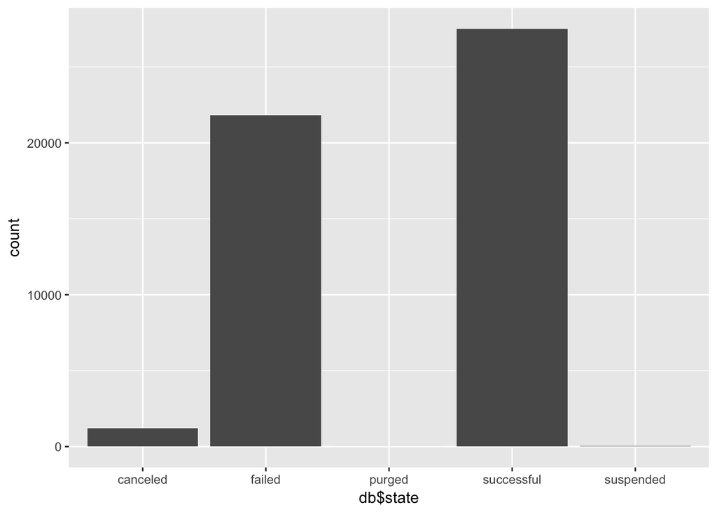

```r
# Most projects are successful or failed, but there are other end states.
db %>%
  ggplot() +
  aes(db$state) +
  geom_histogram(stat = "count")
```

## 0.4 Check redundant variables

```r
# Returns 'COMPLETE' if two columns are exactly the same.
#Returns 'FALSE', 'COMPLETE' if two columns are different.
redundant <- function(x, y) {
  i <- 1
  if(x[i] == y[i]) {
    i = i + 1
    } else {
      print("FALSE")
      i = i + 1
    }
  print("COMPLETE")
}

# Six variables in db are redundant
redundant(db$profile_id, db$profile_project_id)
```

```
## [1] "COMPLETE"
```

```r
redundant(db$currency, db$current_currency)
```

```
## [1] "COMPLETE"
```

```r
redundant(db$pledged, db$usd_pledged)
```

```
## [1] "COMPLETE"
```

```r
redundant(db$location_localized_name, db$location_name)
```

```
## [1] "COMPLETE"
```

```r
redundant(db$location_displayable_name, db$location_short_name)
```

```
## [1] "COMPLETE"
```

```r
redundant(db$profile_id, db$profile_project_id)
```

```
## [1] "COMPLETE"
```

## 0.5 Check variables with only one level

```r
# Six variables with only one level; remove these in db_cleaned.
for (j in 1:ncol(db)) {
  if (length(unique(db[[j]])) == 1) {
    print(colnames(db)[j])
  }
}
```

```
## [1] "creator_is_registered"
## [1] "current_currency"
## [1] "is_starrable"
## [1] "items"
## [1] "livestreams"
## [1] "usd_type"
```

## 0.6 Reformat variables

```r
# Remove meaningless character strings
db$project_id[] <- lapply(db$project_id, gsub, pattern = 'kkst', replacement = '')
db[] <- lapply(db, gsub, pattern = '&#39;', replacement = '')
db[] <- lapply(db, gsub, pattern = ' &amp; ', replacement = '&')
db$category_slug[] <- lapply(db$category_slug, gsub, pattern = ' ', replacement = '_')

# SQL database imported all variables as character type; change non-character variables.
db$project_id <- as.integer(db$project_id)
db$backers_count <- as.integer(db$backers_count)
db$canceled_at <- as.Date(anytime(as.numeric(db$canceled_at)))
db$category_color <- as.integer(db$category_color)
db$category_id <- as.integer(db$category_id)
db$category_parent_id <- as.integer(db$category_parent_id)
db$category_position <- as.integer(db$category_position)
db$comments_count <- as.integer(db$comments_count)
db$converted_pledged_amount <- round(as.numeric(db$converted_pledged_amount), 2)
db$created_at <- as.Date(anytime(as.numeric(db$created_at)))
db$creator_id <- as.integer(db$creator_id)
db$deadline <- as.Date(anytime(as.numeric(db$deadline)))
db$failed_at <- as.Date(anytime(as.numeric(db$failed_at)))
db$fx_rate <- round(as.numeric(db$fx_rate), 2)
db$goal <- round(as.numeric(db$goal), 2)
db$id <- as.integer(db$id)
db$launched_at <- as.Date(anytime(as.numeric(db$launched_at)))
db$location_id <- as.integer(db$location_id)
db$pledged <- round(as.numeric(db$pledged), 2)
db$potd_at <- as.Date(anytime(as.numeric(db$potd_at)))
db$profile_background_image_attributes_id <- as.integer(db$profile_background_image_attributes_id)
db$profile_background_image_opacity <- round(as.numeric(db$profile_background_image_opacity), 1)
db$profile_feature_image_attributes_id <- as.integer(db$profile_feature_image_attributes_id)
db$profile_id <- as.integer(db$profile_id)
db$profile_link_text_color <- as.integer(db$profile_link_text_color)
db$profile_project_id <- as.integer(db$profile_project_id)
db$profile_state_changed_at <- as.Date(anytime(as.numeric(db$profile_state_changed_at)))
db$state_changed_at <- as.Date(anytime(as.numeric(db$state_changed_at)))
db$static_usd_rate <- round(as.numeric(db$static_usd_rate), 2)
db$successful_at <- as.Date(anytime(as.numeric(db$successful_at)))
db$suspended_at <- as.Date(anytime(as.numeric(db$suspended_at)))
db$updated_at <- as.Date(anytime(as.numeric(db$updated_at)))
db$updates_count <- as.integer(db$updates_count)
db$usd_pledged <- round(as.numeric(db$usd_pledged), 2)
db$video_height <- as.integer(db$video_height)
db$video_id <- as.integer(db$video_id)
db$video_width <- as.integer(db$video_width)
```

## 0.7 Make db_cleaned

```r
# Remove unecessary variables
db_cleaned <- dplyr::select(db,
                     -category_id, -category_color, -category_position, -category_name,
                     -category_urls_web_discover,
                     -creator_avatar_medium, -creator_avatar_small, -creator_avatar_thumb,
                     -creator_chosen_currency,
                     -creator_id, -creator_slug,
                     -creator_is_registered,
                     -creator_urls_api_user, -creator_urls_web_user,
                     -currency_symbol, -currency_trailing_code, -current_currency,
                     -disable_communication,
                     -id,
                     -is_starrable,
                     -items,
                     -livestreams,
                     -location_country, -location_id, -location_is_root,
                     -location_localized_name, -location_short_name, -location_slug,
                     -location_urls_api_nearby_projects, -location_urls_web_discover, -location_urls_web_location,
                     -photo_1024x576, -photo_1536x864,
                     -photo_ed, -photo_full, -photo_little, -photo_med, -photo_small, -photo_thumb,
                     -profile_background_color, -profile_background_image_attributes_id,
                     -profile_background_image_attributes_image_urls_baseball_card,
                     -profile_background_image_attributes_image_urls_default, -profile_background_image_opacity,
                     -profile_feature_image_attributes_id,
                     -profile_feature_image_attributes_image_urls_baseball_card,
                     -profile_feature_image_attributes_image_urls_default,
                     -profile_id, -profile_project_id,
                     -profile_link_background_color, -profile_link_text, -profile_link_text_color,
                     -profile_link_url, -profile_name,
                     -profile_should_show_feature_image_section, -profile_show_feature_image,
                     -profile_text_color,
                     -slug,
                     -suspended_at, -canceled_at, -potd_at, -profile_state_changed_at,
                     -urls_api_comments, -urls_api_project, -urls_api_updates,
                     -urls_web_project, -urls_web_project_short, -urls_web_rewards, -urls_web_updates,
                     -usd_pledged, -usd_type, -video,
                     -video_base, -video_frame, -video_height, -video_high, -video_hls, -video_id, -video_width)

# Additional feature engineering
db_cleaned <- mutate(db_cleaned,
                     social_media = as.numeric(as.character(factor(
                       (!is.na(facebook) & !is.na(twitter) & !is.na(youtube)), labels = c(0, 1)))),
                     description_length = nchar(full_description),
                     campaign_duration = round((deadline - launched_at), 2),
                     avg_contribution = round((pledged/backers_count), 2),
                     percent_funded = round((pledged/goal*100), 2))


# Consider only failed or successful projects for binomial classification
state_list <- c("failed", "successful")
db_cleaned <- db_cleaned[db_cleaned$state %in% state_list,]
rm(state_list)

# Use NA to replace 'None'
db_cleaned$profile_blurb[] <- lapply(db_cleaned$profile_blurb, gsub, pattern = 'None', replacement = NA)

# Use 0/1 to replace 'False'/'True' and 'failed'/'successful'
# Photo - has (1), does not have (0)
db_cleaned$photo_key[!is.na(db_cleaned$photo_key)] <- 1
db_cleaned$photo_key[is.na(db_cleaned$photo_key)] <- 0
# Video - has (1), does not have (0)
db_cleaned$video_status[!is.na(db_cleaned$video_status)] <- 1
db_cleaned$video_status[is.na(db_cleaned$video_status)] <- 0
# Spotlight - false (0), true (1)
db_cleaned$spotlight <- as.numeric(as.character(factor(db_cleaned$spotlight, labels = c(0, 1))))
# Staff pick - false (0), true (1)
db_cleaned$staff_pick <- as.numeric(as.character(factor(db_cleaned$staff_pick, labels = c(0, 1))))
# state - failed (0), successful (1)
db_cleaned$state <- as.numeric(as.character(factor(db_cleaned$state, labels = c(0, 1))))
```

## 0.8 Determine Outcome Variable Methodology

After examining the discrepencies between state: “successful” and goal_met, we select $state to produce our outcome variable.

```r
#Isolate relevant variables into df_success
df_success <- db_cleaned[, c("pledged", "state", "goal")]

#Add $goal_met
df_success$goal_met <- df_success$pledged >= df_success$goal

#Compare $state to $goal_met
df_success$successful <- df_success$state == 1
(mean(df_success$goal_met == df_success$successful))
```

```
## [1] 0.999919
```

```r
#Explore the errors
df_errors <- df_success[df_success$goal_met != df_success$successful,]
df_errors
```

```
##        pledged state  goal goal_met successful
## 8246   7999.65     1  8000    FALSE       TRUE
## 14635 10797.00     0 10000     TRUE      FALSE
## 28812  3087.50     0  3000     TRUE      FALSE
## 50189 23020.01     0 23000     TRUE      FALSE
```

```r
#Clean Up
rm(df_success)
rm(df_errors)
```

#### 0.8.0.1 Data Dictionary

```r
# Create data frame
dictionary <- as.data.frame(matrix(0, nrow = 125, ncol = 4,
                                   dimnames = list(NULL, c("name", "description", "type", "values"))))

# Populate the first column of the data frame with the variable names from db
dictionary$name <- c(colnames(db),
                     "social_media",
                     "description_length",
                     "campaign_duration",
                     "avg_contribution",
                     "percent_funded")

# Manually write in definitions in the second column of the data frame
#dictionary$description <- c()

# Populate the third column with the variable type
dictionary$type <- c(sapply(db, class),
                     typeof(db_cleaned$social_media),
                     typeof(db_cleaned$description_length),
                     typeof(db_cleaned$campaign_duration),
                     typeof(db_cleaned$avg_contribution),
                     typeof(db_cleaned$percent_funded))

# Popoulate the fourth column with possible values and meanings
#dictionary$values <- c(sapply(db, range),
#                       range(db_cleaned$social_media),
#                       range(db_cleaned$description_length),
#                       range(db_cleaned$campaign_duration),
#                       range(db_cleaned$avg_contribution),
#                       range(db_cleaned$percent_funded))
```

#### 0.8.0.2 Exploratory Analysis

## 0.9 Explore $project_id

## 0.10 Explore $backers_count

Backers count is a very strong predictor of success. We can see from the the logistic model that after ~75 backers succcess is almost guranteed. However, we are focusing on variables at the begining of a project.

```r
#Check for NA
anyNA(db_cleaned$backers_count)
```

```
## [1] FALSE
```

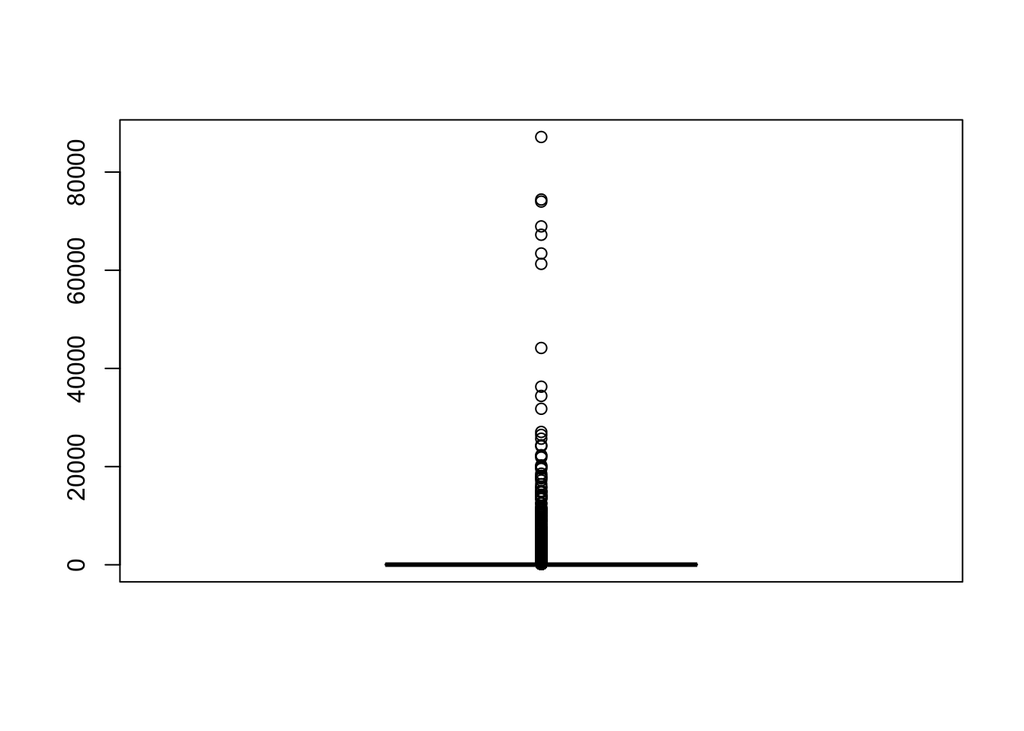

```r
#Box Plot
boxplot(db_cleaned$backers_count)
```

```r
#Linear Model
#significant
lm_backers_count <- glm(percent_funded ~ backers_count, data = db_cleaned)
summary(lm_backers_count)
```

```
##
## Call:
## glm(formula = percent_funded ~ backers_count, data = db_cleaned)
##
## Deviance Residuals:
##     Min       1Q   Median       3Q      Max
##  -29145     -280     -232     -184  4152668
##
## Coefficients:
##                Estimate Std. Error t value Pr(>|t|)
## (Intercept)   280.08143  104.39625   2.683 0.007302 **
## backers_count   0.34081    0.09289   3.669 0.000244 ***
## ---
## Signif. codes:  0 '***' 0.001 '**' 0.01 '*' 0.05 '.' 0.1 ' ' 1
##
## (Dispersion parameter for gaussian family taken to be 530074961)
##
##     Null deviance: 2.6167e+13  on 49353  degrees of freedom
## Residual deviance: 2.6160e+13  on 49352  degrees of freedom
## AIC: 1131514
##
## Number of Fisher Scoring iterations: 2
```

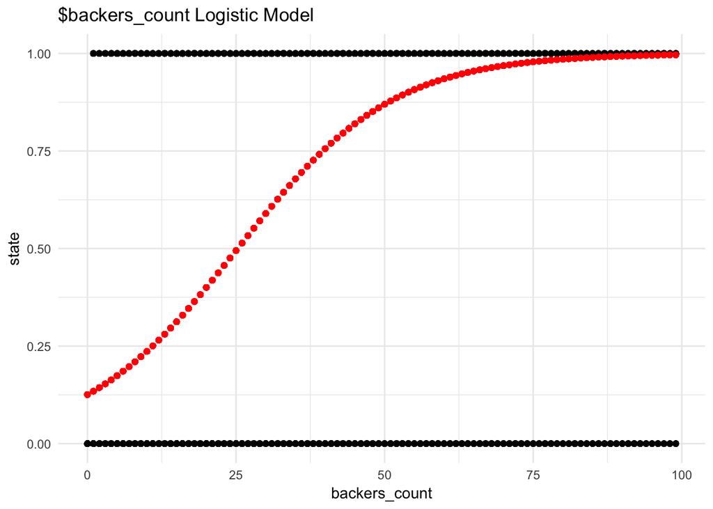

```r
#Logit; Filtered for visual
df_backers_count_filtered <- db_cleaned %>%
  filter(backers_count < 100)

logit_backers_count <- glm(state ~ backers_count,
                           data = df_backers_count_filtered,
                           family = binomial(link='logit'))

df_backers_count_filtered %>%
  ggplot() +
  theme_minimal() +
  ggtitle("$backers_count Logistic Model") +
  geom_point(aes(x=backers_count, y=state), colour = "black") +
  geom_point(aes(x=backers_count, y=logit_backers_count$fitted.values), colour = "red")
```

```r
#Clean Up
rm(lm_backers_count)
rm(df_backers_count_filtered)
rm(logit_backers_count)
```

## 0.11 Explore category variables

$category_parent_id, $category_slug - Some categories never fail in this dataset (only considered if n > 50): - design/product design (1098 projects) - film & video/documentary (2203 projects) - film & video/shorts (3513 projects) - games/tabletop games (1064 projects) - Most successful parent categories (only considered if n > 100): - 7 1,725 projects 81.2% successful - 11 12,088 projects 65.2% successful - 14 14,637 projects 59.2% successful - Least successful parent categories (only considered if n > 100): - 18 8,726 projects 39.7% successful - 16 1,638 projects 46.2% successful - 12 4,125 projects 46.9% successful

```r
# By main category
# 15 unique categories
db_cleaned %>%
  group_by(category_parent_id) %>%
  summarise(n(),
            success_rate = round(mean(state)*100, 2),
            mean(goal, na.rm = TRUE),
            min(percent_funded, na.rm = TRUE),
            median(percent_funded, na.rm = TRUE),
            max(percent_funded, na.rm = TRUE),
            mean(percent_funded, na.rm = TRUE),
            mean(backers_count),
            min(backers_count),
            median(backers_count),
            max(backers_count),
            mean(avg_contribution, na.rm = TRUE),
            min(avg_contribution, na.rm = TRUE),
            median(avg_contribution, na.rm = TRUE),
            max(avg_contribution, na.rm = TRUE)) %>%
  ungroup(category_parent_id)
```

```
## # A tibble: 15 x 16
##    category_parent_… `n()` success_rate `mean(goal, na.… `min(percent_fun…
##                <int> <int>        <dbl>            <dbl>             <dbl>
##  1                 1  6122         51.2            9139.                0
##  2                 3    57        100             11760.              102.
##  3                 6    11        100              3165.              102.
##  4                 7  1725         81.2           12981.                0
##  5                 9    36        100             18178.              101.
##  6                10    45        100             19737.              100.
##  7                11 12088         65.2           22408.                0
##  8                12  4125         46.9           38009.                0
##  9                13    15        100             23405               100
## 10                14 14637         59.2            7590.                0
## 11                15    11        100              9061.              101.
## 12                16  1638         46.2           68119.                0
## 13                17    57        100              5994.              100
## 14                18  8726         39.7            7951.                0
## 15                26    61         96.7            3235.                0
## # ... with 11 more variables: `median(percent_funded, na.rm =
## #   TRUE)` <dbl>, `max(percent_funded, na.rm = TRUE)` <dbl>,
## #   `mean(percent_funded, na.rm = TRUE)` <dbl>,
## #   `mean(backers_count)` <dbl>, `min(backers_count)` <dbl>,
## #   `median(backers_count)` <dbl>, `max(backers_count)` <dbl>,
## #   `mean(avg_contribution, na.rm = TRUE)` <dbl>, `min(avg_contribution,
## #   na.rm = TRUE)` <dbl>, `median(avg_contribution, na.rm = TRUE)` <dbl>,
## #   `max(avg_contribution, na.rm = TRUE)` <dbl>
```

```r
# By subcategory
# 140 unique category/subcategory combinations
db_cleaned %>%
  group_by(as.character(category_slug)) %>%
  summarise(n(),
            success_rate = round(mean(state)*100, 2),
            min(percent_funded, na.rm = TRUE),
            median(percent_funded, na.rm = TRUE),
            max(percent_funded, na.rm = TRUE),
            mean(percent_funded, na.rm = TRUE),
            mean(backers_count),
            min(backers_count),
            median(backers_count),
            max(backers_count),
            mean(avg_contribution, na.rm = TRUE),
            min(avg_contribution, na.rm = TRUE),
            median(avg_contribution, na.rm = TRUE),
            max(avg_contribution, na.rm = TRUE)) %>%
  ungroup(category_slug)
```

```
## # A tibble: 140 x 15
##    `as.character(ca… `n()` success_rate `min(percent_fun… `median(percent…
##    <chr>             <int>        <dbl>             <dbl>            <dbl>
##  1 art/ceramics          7        100                103.            125.
##  2 art/conceptual_a…   127         47.2                0              44.6
##  3 art/digital_art     114         53.5                0             101.
##  4 art/illustration    600         52.2                0             100.
##  5 art/installations     6        100                102.            128.
##  6 art/mixed_media    1034         44.8                0              35.5
##  7 art/painting       1125         47.7                0              50.2
##  8 art/performance_…  1109         53.6                0             100.
##  9 art/public_art     1349         61.8                0             102.
## 10 art/sculpture       646         39.2                0              21.7
## # ... with 130 more rows, and 10 more variables: `max(percent_funded,
## #   na.rm = TRUE)` <dbl>, `mean(percent_funded, na.rm = TRUE)` <dbl>,
## #   `mean(backers_count)` <dbl>, `min(backers_count)` <dbl>,
## #   `median(backers_count)` <dbl>, `max(backers_count)` <dbl>,
## #   `mean(avg_contribution, na.rm = TRUE)` <dbl>, `min(avg_contribution,
## #   na.rm = TRUE)` <dbl>, `median(avg_contribution, na.rm = TRUE)` <dbl>,
## #   `max(avg_contribution, na.rm = TRUE)` <dbl>
```

```r
#Logit
db_cleaned$category_parent_id <- as.factor(db_cleaned$category_parent_id)
logit_category <- glm(state ~ category_parent_id, data = db_cleaned, family = binomial(link='logit'))
summary(logit_category)
```

```
##
## Call:
## glm(formula = state ~ category_parent_id, family = binomial(link = "logit"),
##     data = db_cleaned)
##
## Deviance Residuals:
##     Min       1Q   Median       3Q      Max
## -2.6145  -1.1975   0.9256   1.0245   1.3587
##
## Coefficients:
##                       Estimate Std. Error z value Pr(>|z|)
## (Intercept)            0.04705    0.02557   1.840 0.065732 .
## category_parent_id3   14.51902  116.92222   0.124 0.901175
## category_parent_id6   14.51902  266.15714   0.055 0.956497
## category_parent_id7    1.41715    0.06674  21.235  < 2e-16 ***
## category_parent_id9   14.51902  147.12390   0.099 0.921388
## category_parent_id10  14.51902  131.59162   0.110 0.912145
## category_parent_id11   0.57883    0.03191  18.141  < 2e-16 ***
## category_parent_id12  -0.17085    0.04034  -4.235 2.28e-05 ***
## category_parent_id13  14.51902  227.92336   0.064 0.949208
## category_parent_id14   0.32374    0.03060  10.579  < 2e-16 ***
## category_parent_id15  14.51902  266.15714   0.055 0.956497
## category_parent_id16  -0.19875    0.05577  -3.564 0.000365 ***
## category_parent_id17  14.51902  116.92222   0.124 0.901175
## category_parent_id18  -0.46370    0.03365 -13.780  < 2e-16 ***
## category_parent_id26   3.33734    0.71945   4.639 3.51e-06 ***
## ---
## Signif. codes:  0 '***' 0.001 '**' 0.01 '*' 0.05 '.' 0.1 ' ' 1
##
## (Dispersion parameter for binomial family taken to be 1)
##
##     Null deviance: 67763  on 49353  degrees of freedom
## Residual deviance: 65284  on 49339  degrees of freedom
## AIC: 65314
##
## Number of Fisher Scoring iterations: 13
```

## 0.12 Explore $comments_count

## 0.13 Explore $converted_pledged_amount

Validate hypothesis that $converted_pledged_amount = $fx_rate * $pledged

```r
# fx_rate is the exchange rate to USD
for (i in length(db_cleaned$converted_pledged_amount)) {
  if (db_cleaned$converted_pledged_amount[i] == db_cleaned$fx_rate[i]*db_cleaned$pledged[i]) {
    i = i + 1
  } else {
    print("FALSE")
  }
  print("COMPLETE")
}
```

```
## [1] "COMPLETE"
```

## 0.14 Explore date-time variables

```r
# created_at, deadline, failed_at, launched_at, state_changed_at, successful_at, updated_at
ticktock <- data.frame(db_cleaned$created_at,
                       db_cleaned$deadline,
                       db_cleaned$failed_at,
                       db_cleaned$launched_at,
                       db_cleaned$state_changed_at,
                       db_cleaned$successful_at)

# variables to assess differences
ticktock <- mutate(ticktock,
                   deadline_failed = db_cleaned.deadline - db_cleaned.failed_at,
                   deadline_success = db_cleaned.deadline - db_cleaned.successful_at,
                   deadline_state = db_cleaned.deadline - db_cleaned.state_changed_at)

# an average of 2-20 minutes difference btween deadline and failed_at, successful_at, state_changed_at
mean(ticktock$deadline_failed, na.rm = TRUE)
```

```
## Time difference of -0.01497664 days
```

```r
mean(ticktock$deadline_success, na.rm = TRUE)
```

```
## Time difference of -0.001453488 days
```

```r
mean(ticktock$deadline_state)
```

```
## Time difference of -0.007436074 days
```

```r
# drop from data frame
db_cleaned <- dplyr::select(db_cleaned, -failed_at, -successful_at, -state_changed_at)

# Clean up
rm(ticktock)

# Add variables for more meaningful time grouping
db_cleaned$date_launched <- as.Date(db_cleaned$launched_at, format="%m/%d/%Y")
db_cleaned$mo_yr_launched <- format(db_cleaned$date_launched, format="%Y-%m")
db_cleaned$year_launched <- format(db_cleaned$date_launched, format="%Y")
```

## 0.15 Explore $disable_communication

This is not a user initiated setting, rather an effect of a project being suspended.

```r
df_filtered_disable_communicaiotn <- db %>%
  filter(disable_communication == "True")

df_filtered_state_suspended <- db %>%
  filter(state == "suspended")

rownames(df_filtered_disable_communicaiotn) == rownames(df_filtered_state_suspended)
```

```
##  [1] TRUE TRUE TRUE TRUE TRUE TRUE TRUE TRUE TRUE TRUE TRUE TRUE TRUE TRUE
## [15] TRUE TRUE TRUE TRUE TRUE TRUE TRUE TRUE TRUE TRUE
```

```r
#Clean Up
rm(df_filtered_disable_communicaiotn)
rm(df_filtered_state_suspended)
```

## 0.16 Explore $goal

Goal is likely a good predicter

```r
db_cleaned$goal %>%
  summary()
```

```
##     Min.  1st Qu.   Median     Mean  3rd Qu.     Max.
##        0     1800     4500    16235    10000 21474836
```

```r
#Linear Model
#not significant
lm_goal <- glm(percent_funded ~ goal, data = db_cleaned)
summary(lm_goal)
```

```
##
## Call:
## glm(formula = percent_funded ~ goal, data = db_cleaned)
##
## Deviance Residuals:
##     Min       1Q   Median       3Q      Max
##    -328     -320     -226     -211  4153173
##
## Coefficients:
##               Estimate Std. Error t value Pr(>|t|)
## (Intercept)  3.277e+02  1.039e+02   3.153  0.00162 **
## goal        -8.838e-05  4.690e-04  -0.188  0.85055
## ---
## Signif. codes:  0 '***' 0.001 '**' 0.01 '*' 0.05 '.' 0.1 ' ' 1
##
## (Dispersion parameter for gaussian family taken to be 530219177)
##
##     Null deviance: 2.6167e+13  on 49353  degrees of freedom
## Residual deviance: 2.6167e+13  on 49352  degrees of freedom
## AIC: 1131527
##
## Number of Fisher Scoring iterations: 2
```

[figure not shown]

```r
#Logit; Filtered for visual
df_filtered_by_goal <- db_cleaned %>%
  filter(goal < 200000)

logit_goal <- glm(state ~ goal, data = df_filtered_by_goal, family=binomial(link='logit'))

df_filtered_by_goal %>%
  ggplot() +
  theme_minimal() +
  ggtitle("$backers_count Logistic Model") +
  geom_point(aes(x=goal, y=state), colour = "black") +
  geom_point(aes(x=goal, y=logit_goal$fitted.values), colour = "red")
```

```r
# Group into deciles and look as level
```

## 0.17 Explore $launched_at

```r
db_cleaned %>%
  filter(!is.na(percent_funded) & percent_funded <= 400) %>%
  group_by(mo_yr_launched)  %>%
  summarise(n(),
            success_rate = round(mean(state)*100, 2),
            mean(percent_funded, na.rm = TRUE),
            mean (avg_contribution, na.rm = TRUE))
```

```
## # A tibble: 57 x 5
##    mo_yr_launched `n()` success_rate `mean(percent_fun… `mean(avg_contrib…
##    <chr>          <int>        <dbl>              <dbl>              <dbl>
##  1 2009-04            7         71.4              137.                14.6
##  2 2009-05           30         60                 87.4               44.3
##  3 2009-06           31         48.4               69.1               55.8
##  4 2009-07           35         57.1               78.3               90.7
##  5 2009-08           50         54                 80.2               78.7
##  6 2009-09          152         44.1               59.7               66.0
##  7 2009-10           87         52.9               69.7               68.3
##  8 2009-11           93         64.5               85.3               69.0
##  9 2009-12           86         66.3               86.3               71.4
## 10 2010-01          117         58.1               78.2               68.7
## # ... with 47 more rows
```

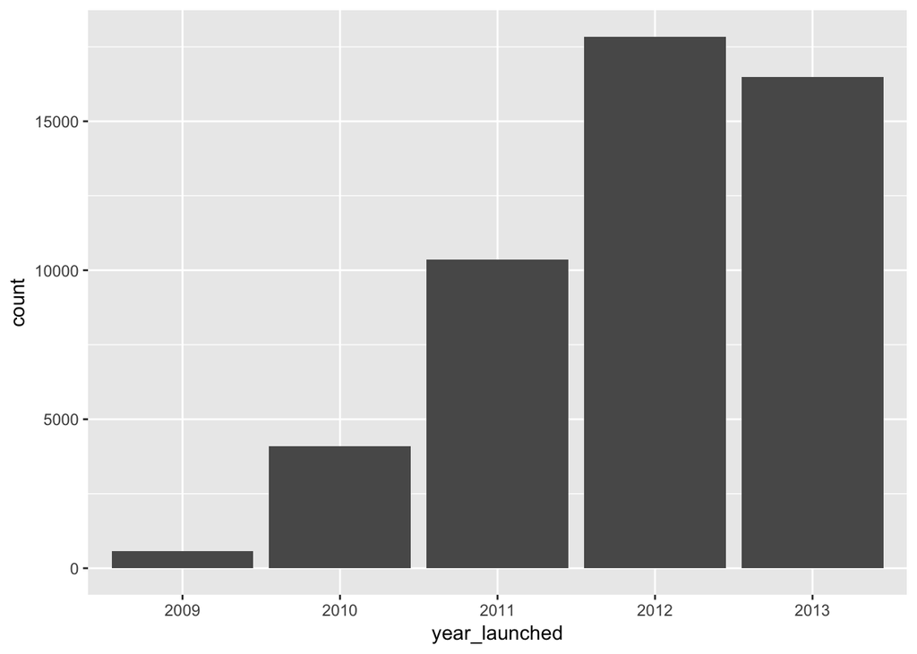

```r
db_cleaned %>%
  ggplot() +
  geom_histogram(aes(x=year_launched), stat = "count")
```

## 0.18 Explore location variables

$country, $location_displayable_name, $location_name, $location_state, $location_type

## 0.19 Explore $photo_key

## 0.20 Explore $pledged

```r
# Group into deciles and look as levels
```

## 0.21 Explore profile variables

$profile_blurb, $profile_state

## 0.22 Explore $rewards

## 0.23 Explore $spotlight

## 0.24 Explore $staff_pick

## 0.25 Explore $state

```r
db_cleaned %>%
  group_by(state) %>%
  summarise(n(),
            mean(percent_funded, na.rm = TRUE),
            mean(avg_contribution, na.rm = TRUE),
            mean(goal, na.rm = TRUE),
            min(percent_funded, na.rm = TRUE),
            median(percent_funded, na.rm = TRUE),
            max(percent_funded, na.rm = TRUE),
            mean(backers_count),
            min(backers_count),
            median(backers_count),
            max(backers_count),
            mean(avg_contribution, na.rm = TRUE),
            min(avg_contribution, na.rm = TRUE),
            median(avg_contribution, na.rm = TRUE),
            max(avg_contribution, na.rm = TRUE)) %>%
  ungroup(state)
```

```
## # A tibble: 2 x 15
##   state `n()` `mean(percent_funde… `mean(avg_contributi… `mean(goal, na.r…
##   <dbl> <int>                <dbl>                 <dbl>             <dbl>
## 1     0 21834                 10.6                  57.2            26045.
## 2     1 27520                577.                   82.9             8453.
## # ... with 10 more variables: `min(percent_funded, na.rm = TRUE)` <dbl>,
## #   `median(percent_funded, na.rm = TRUE)` <dbl>, `max(percent_funded,
## #   na.rm = TRUE)` <dbl>, `mean(backers_count)` <dbl>,
## #   `min(backers_count)` <dbl>, `median(backers_count)` <dbl>,
## #   `max(backers_count)` <dbl>, `min(avg_contribution, na.rm =
## #   TRUE)` <dbl>, `median(avg_contribution, na.rm = TRUE)` <dbl>,
## #   `max(avg_contribution, na.rm = TRUE)` <dbl>
```

## 0.26 Explore $updates_count

## 0.27 Explore $video_status

T test shows having a video to statistically significantly impact the success of the project.

```r
t.test(state ~ video_status, data = db_cleaned)
```

```
##
##  Welch Two Sample t-test
##
## data:  state by video_status
## t = -31.722, df = 13074, p-value < 2.2e-16
## alternative hypothesis: true difference in means is not equal to 0
## 95 percent confidence interval:
##  -0.1939800 -0.1714025
## sample estimates:
## mean in group 0 mean in group 1
##       0.4077910       0.5904823
```

## 0.28 Explore social media connectedness variables

$facebook, $twitter, $youtube $social_media

## 0.29 Explore $description_length

## 0.30 Explore $campaign_duration

```r
#Linear Model
#not significant
lm_length <- glm(percent_funded ~ campaign_duration, data = db_cleaned)
summary(lm_goal)
```

```
##
## Call:
## glm(formula = percent_funded ~ goal, data = db_cleaned)
##
## Deviance Residuals:
##     Min       1Q   Median       3Q      Max
##    -328     -320     -226     -211  4153173
##
## Coefficients:
##               Estimate Std. Error t value Pr(>|t|)
## (Intercept)  3.277e+02  1.039e+02   3.153  0.00162 **
## goal        -8.838e-05  4.690e-04  -0.188  0.85055
## ---
## Signif. codes:  0 '***' 0.001 '**' 0.01 '*' 0.05 '.' 0.1 ' ' 1
##
## (Dispersion parameter for gaussian family taken to be 530219177)
##
##     Null deviance: 2.6167e+13  on 49353  degrees of freedom
## Residual deviance: 2.6167e+13  on 49352  degrees of freedom
## AIC: 1131527
##
## Number of Fisher Scoring iterations: 2
```

```r
#Logit
#significant
logit_length <- glm(state ~ campaign_duration, data = db_cleaned, family=binomial(link='logit'))
summary(logit_length)
```

```
##
## Call:
## glm(formula = state ~ campaign_duration, family = binomial(link = "logit"),
##     data = db_cleaned)
##
## Deviance Residuals:
##    Min      1Q  Median      3Q     Max
## -1.512  -1.309   0.989   1.045   1.464
##
## Coefficients:
##                     Estimate Std. Error z value Pr(>|z|)
## (Intercept)        0.7898045  0.0244214   32.34   <2e-16 ***
## campaign_duration -0.0156685  0.0006354  -24.66   <2e-16 ***
## ---
## Signif. codes:  0 '***' 0.001 '**' 0.01 '*' 0.05 '.' 0.1 ' ' 1
##
## (Dispersion parameter for binomial family taken to be 1)
##
##     Null deviance: 67763  on 49353  degrees of freedom
## Residual deviance: 67140  on 49352  degrees of freedom
## AIC: 67144
##
## Number of Fisher Scoring iterations: 4
```

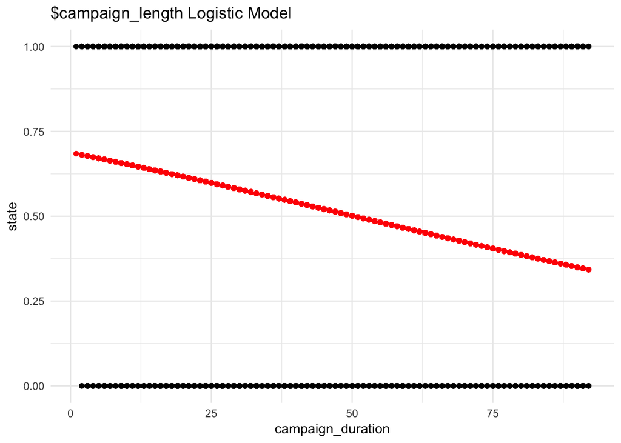

```r
db_cleaned %>%
  ggplot() +
  theme_minimal() +
  ggtitle("$campaign_length Logistic Model") +
  geom_point(aes(x=campaign_duration, y=state), colour = "black") +
  geom_point(aes(x=campaign_duration, y=logit_length$fitted.values), colour = "red")
```